# 新聞數據視覺化：失聯移工是誰？

## 4. 矛盾與推力：雇主眼中的原因 vs. 殘酷的現實

當雇主被問及「移工為什麼失聯」時，他們是怎麼回答的？

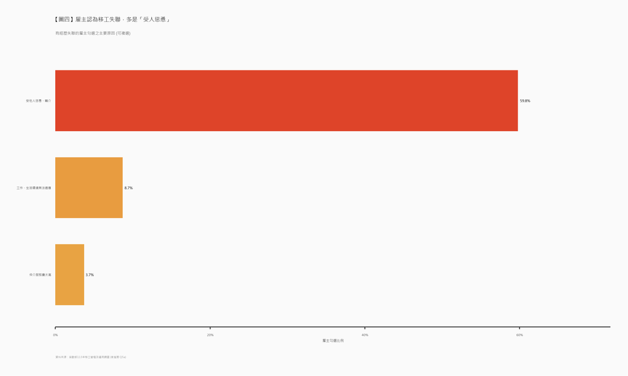

```r
# 分析 Q5a：雇主認為的外籍家庭看護工行蹤不明失聯原因 (複選)
q5a_vars   <- paste0("q5a_", 1:9)
q5a_labels <- c("受他人慫恿、轉介", "希望獲得較高待遇", "聘僱期限即將届滿",
                "賭博欠債或犯法逃逸", "相處不融洽", "工作、生活環境無法適應",
                "仲介服務費太高", "勞資爭議", "其他")

df_q5 <- data113 %>% filter(q5 == 2) %>% mutate(權重 = as.numeric(w))
total_w <- sum(df_q5$權重, na.rm = TRUE)

q5a_df <- df_q5 %>%
  select(all_of(q5a_vars), 權重) %>%
  pivot_longer(cols = all_of(q5a_vars), names_to = "item", values_to = "val") %>%
  filter(val == 1) %>%
  group_by(item) %>%
  summarise(n_w = sum(權重, na.rm = TRUE), .groups = "drop") %>%
  mutate(
    label = q5a_labels[match(item, q5a_vars)],
    pct   = n_w / total_w
  ) %>%
  filter(label %in% c("受他人慫恿、轉介", "工作、生活環境無法適應", "仲介服務費太高")) %>%
  arrange(desc(pct)) %>%
  mutate(label = fct_reorder(label, pct))

ggplot(q5a_df, aes(x = pct, y = label)) +
  geom_col(aes(fill = pct), width = 0.7, show.legend = FALSE) +
  geom_text(aes(label = percent(pct, 0.1)), hjust = -0.2, fontface = "bold", size = 4.5) +
  scale_fill_gradient(low = reporter_yellow, high = reporter_orange) +
  scale_x_continuous(labels = percent, expand = expansion(mult = c(0, 0.2))) +
  labs(title = "【圖四】雇主認為移工失聯，多是「受人慫恿」",
       subtitle = "有經歷失聯的雇主勾選之主要原因 (可複選)",
       x = "雇主勾選比例", y = NULL,
       caption = "資料來源：勞動部113年移工管理及運用調查 (家庭面 Q5a)") +
  theme_news() +
  theme(panel.grid.major.y = element_blank())
```

## 5. 為什麼他們要跑？勞動條件的結構性落差

雇主看到的往往是外部誘惑（如受人慫恿），但客觀數據呈現的卻是殘酷的推力：家庭看護工的薪水遠低於產業移工，且幾乎沒有休假，這直接反映在他們雙方失聯率的反差上。

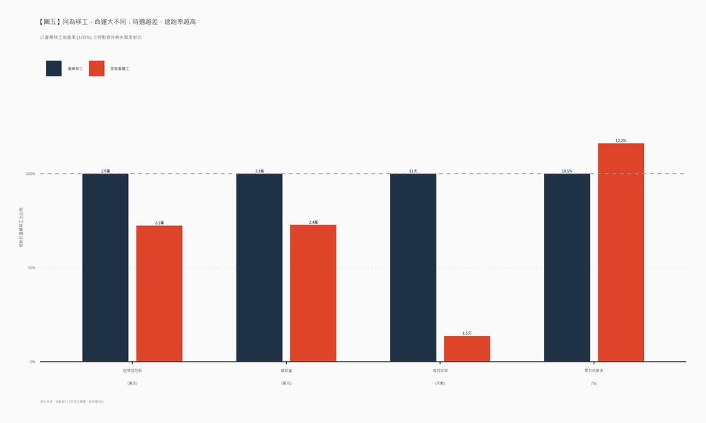

```r
# 勞動條件比較 (113年資料) + 2025失聯率
conditions <- tibble(
  項目 = rep(c("經常性月薪\n(萬元)", "每月放假\n(天數)", "總薪資\n(萬元)", "累計失聯率\n(%)"), each = 2),
  類別 = rep(c("產業移工", "家庭看護工"), 4),
  數值 = c(
    2.9, 2.1,   # 經常性月薪
    11, 1.5,    # 每月放假
    3.3, 2.4,   # 總薪資
    10.5, 12.2  # 累計失聯率
  )
) %>%
  mutate(
    項目 = factor(項目, levels = c("經常性月薪\n(萬元)", "總薪資\n(萬元)", "每月放假\n(天數)", "累計失聯率\n(%)")),
    類別 = factor(類別, levels = c("產業移工", "家庭看護工"))
  )

# 計算相對於產業移工的比例 (產業移工 = 1)
conditions_norm <- conditions %>%
  group_by(項目) %>%
  mutate(
    基準 = 數值[類別 == "產業移工"],
    相對比例 = 數值 / 基準,
    標籤 = case_when(
      str_detect(項目, "失聯率") ~ paste0(數值, "%"),
      str_detect(項目, "天數") ~ paste0(數值, "天"),
      TRUE ~ paste0(數值, "萬")
    )
  ) %>%
  ungroup()

ggplot(conditions_norm, aes(x = 項目, y = 相對比例, fill = 類別)) +
  geom_col(position = position_dodge(width = 0.7), width = 0.6) +
  geom_text(aes(label = 標籤),
            position = position_dodge(width = 0.7), vjust = -0.5,
            fontface = "bold", size = 4.2) +
  geom_hline(yintercept = 1, linetype = "dashed", color = "#999999") +
  scale_fill_manual(values = c("產業移工" = reporter_dark, "家庭看護工" = reporter_orange)) +
  scale_y_continuous(labels = percent_format(), limits = c(0, 1.3), expand = expansion(mult = c(0, 0.1))) +
  labs(title = "【圖五】同為移工，命運大不同：待遇越差、逃跑率越高",
       subtitle = "以產業移工為基準 (100%) 之勞動條件與失聯率對比",
       x = NULL, y = "相對於產業移工之比例",
       caption = "資料來源：勞動部113年移工調查、移民署統計") +
  theme_news() +
  theme(axis.text.x = element_text(face = "bold", size = 12))
```

> **專題總結：** 近六成雇主認為移工逃跑是因為「受他人慫恿」，然而只有不到 4% 的雇主認為是「仲介費太高」。 這突顯了巨大的認知落差：雇主看到的往往是外部誘惑，卻沒看見移工背負的高額債務（圖二）、每月極低的放假天數，以及遠低於基本工資的薪資。**「失聯」並非單純的個人道德瑕疵，而是制度性勞動條件落差下，移工「不跑不行」的結構性悲歌。**